# Exercise 3

```python
# If you are running this on Google Colab, uncomment and run the following lines; otherwise ignore this cell
# from google.colab import drive
# drive.mount('/content/drive')
```

```python
import math
import numpy as np
import matplotlib.pyplot as plt
import pandas as pd
```

```python
# Load data
df_tfl = pd.read_csv('tfl_ridership.csv')
# If running on Google Colab change path to '/content/drive/MyDrive/IB-Data-Science/Exercises/tfl_ridership.csv'

df_tfl.head(13)
```

|  | Year | Period | Start | End | Days | Bus cash (000s) | Bus Oyster PAYG (000s) | Bus Contactless (000s) | Bus One Day Bus Pass (000s) | Bus Day Travelcard (000s) | ... | Tube Contactless (000s) | Tube Day Travelcard (000s) | Tube Season Travelcard (000s) | Tube Other incl free (000s) | Tube Total (000s) | TfL Rail (000s) | Overground (000s) | DLR (000s) | Tram (000s) | Air Line (000s) |
| --- | --- | --- | --- | --- | --- | --- | --- | --- | --- | --- | --- | --- | --- | --- | --- | --- | --- | --- | --- | --- | --- |
| 0 | 2000/01 | P 01 | 01 Apr '00 | 29 Apr '00 | 29d | 884 | 0 | 0 | 210 | 231 | ... | 0 | 655 | 1066 | 200 | 2509 | 0 | 0 | 96 | 45.8 | 0.0 |
| 1 | 2000/01 | P 02 | 30 Apr '00 | 27 May '00 | 28d | 949 | 0 | 0 | 214 | 205 | ... | 0 | 605 | 1168 | 217 | 2598 | 0 | 0 | 93 | 46.5 | 0.0 |
| 2 | 2000/01 | P 03 | 28 May '00 | 24 Jun '00 | 28d | 945 | 0 | 0 | 209 | 221 | ... | 0 | 650 | 1154 | 212 | 2623 | 0 | 0 | 98 | 47.1 | 0.0 |
| 3 | 2000/01 | P 04 | 25 Jun '00 | 22 Jul '00 | 28d | 981 | 0 | 0 | 216 | 241 | ... | 0 | 708 | 1196 | 214 | 2761 | 0 | 0 | 105 | 50.8 | 0.0 |
| 4 | 2000/01 | P 05 | 23 Jul '00 | 19 Aug '00 | 28d | 958 | 0 | 0 | 225 | 248 | ... | 0 | 730 | 1165 | 165 | 2643 | 0 | 0 | 103 | 50.3 | 0.0 |
| 5 | 2000/01 | P 06 | 20 Aug '00 | 16 Sep '00 | 28d | 984 | 0 | 0 | 243 | 236 | ... | 0 | 702 | 1164 | 151 | 2608 | 0 | 0 | 100 | 49.2 | 0.0 |
| 6 | 2000/01 | P 07 | 17 Sep '00 | 14 Oct '00 | 28d | 1001 | 0 | 0 | 205 | 216 | ... | 0 | 639 | 1286 | 196 | 2763 | 0 | 0 | 107 | 48.8 | 0.0 |
| 7 | 2000/01 | P 08 | 15 Oct '00 | 11 Nov '00 | 28d | 979 | 0 | 0 | 199 | 221 | ... | 0 | 668 | 1298 | 220 | 2819 | 0 | 0 | 113 | 51.5 | 0.0 |
| 8 | 2000/01 | P 09 | 12 Nov '00 | 09 Dec '00 | 28d | 971 | 0 | 0 | 184 | 212 | ... | 0 | 640 | 1302 | 242 | 2839 | 0 | 0 | 114 | 54.0 | 0.0 |
| 9 | 2000/01 | P 10 | 10 Dec '00 | 06 Jan '01 | 28d | 912 | 0 | 0 | 192 | 211 | ... | 0 | 631 | 993 | 195 | 2359 | 0 | 0 | 90 | 55.3 | 0.0 |
| 10 | 2000/01 | P 11 | 07 Jan '01 | 03 Feb '01 | 28d | 943 | 0 | 0 | 193 | 186 | ... | 0 | 556 | 1259 | 234 | 2634 | 0 | 0 | 110 | 50.1 | 0.0 |
| 11 | 2000/01 | P 12 | 04 Feb '01 | 03 Mar '01 | 28d | 975 | 0 | 0 | 194 | 210 | ... | 0 | 617 | 1237 | 246 | 2688 | 0 | 0 | 120 | 50.5 | 0.0 |
| 12 | 2000/01 | P 13 | 04 Mar '01 | 31 Mar '01 | 28d | 974 | 0 | 0 | 186 | 204 | ... | 0 | 584 | 1262 | 266 | 2699 | 0 | 0 | 119 | 47.7 | 0.0 |

13 rows × 26 columns

Each row of our data frame represents the average daily ridership over a 28/29 day period for various types of transport and tickets (bus, tube etc.). We have used the `.head()` command to display the top 13 rows of the data frame (corresponding to one year). Focusing on the "Tube Total" column, notice the dip in ridership in row 9 (presumably due to Christmas/New Year's), and also the slight dip during the summer (rows 4,5).

```python
#df_tfl.sample(3)  #random sample of 3 rows
df_tfl.tail(3)  #last 3 rows
```

|  | Year | Period | Start | End | Days | Bus cash (000s) | Bus Oyster PAYG (000s) | Bus Contactless (000s) | Bus One Day Bus Pass (000s) | Bus Day Travelcard (000s) | ... | Tube Contactless (000s) | Tube Day Travelcard (000s) | Tube Season Travelcard (000s) | Tube Other incl free (000s) | Tube Total (000s) | TfL Rail (000s) | Overground (000s) | DLR (000s) | Tram (000s) | Air Line (000s) |
| --- | --- | --- | --- | --- | --- | --- | --- | --- | --- | --- | --- | --- | --- | --- | --- | --- | --- | --- | --- | --- | --- |
| 242 | 2018/19 | P 09 | 11 Nov '18 | 08 Dec '18 | 28d | 0 | 1110 | 1089 | 0 | 41 | ... | 1399 | 249 | 1017 | 334 | 4221 | 996 | 557 | 355 | 84.1 | 2.6 |
| 243 | 2018/19 | P 10 | 09 Dec '18 | 05 Jan '19 | 28d | 0 | 1001 | 949 | 0 | 38 | ... | 1110 | 242 | 632 | 259 | 3279 | 750 | 414 | 270 | 66.3 | 3.2 |
| 244 | 2018/19 | P 11 | 06 Jan '19 | 02 Feb '19 | 28d | 0 | 1036 | 1075 | 0 | 30 | ... | 1310 | 204 | 924 | 305 | 3809 | 929 | 517 | 333 | 79.3 | 2.3 |

3 rows × 26 columns

The dataframe contains $N=245$ counting periods (of 28/29 days each) from 1 April 2000 to 2 Feb 2019. We now define a numpy array consisting of the values in the ' Tube Total (000s)' column:

```python
yvals = np.array(df_tfl['Tube Total (000s)'])
N = np.size(yvals)
xvals = np.linspace(1,N,N) #an array containing the values 1,2....,N
```

We now have a time series consisting of points $(x_i,y_i)$, for $i = 1, \ldots, N$, where $y_i$ is the average daily tube rideship in counting period $x_i = i$.

## 2a) Plot the data in a scatterplot

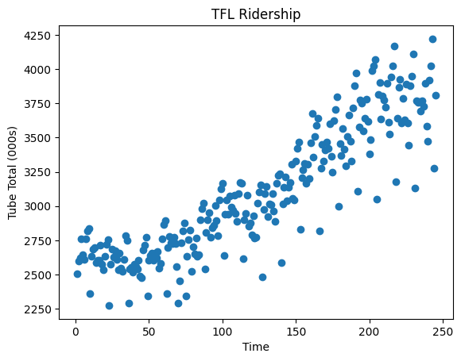

```python
#Your code for scatterplot here
plt.scatter(xvals,yvals)
plt.xlabel('Time')
plt.ylabel('Tube Total (000s)')
plt.title('TFL Ridership')
plt.savefig('Exercise 2 tfl_ridership_scatter data.png')
plt.show()
```

## 2b) Fit a linear model $f(x) = \beta_0 + \beta_1 x$ to the data

- Print the values of the regression coefficients $\beta_0, \beta_1$ determined using least-squares.
- Plot the fitted model and the scatterplot on the same plot.
- Compute and print the **MSE** and the $R^2$ coefficient for the fitted model.

All numerical outputs should be displayed to three decimal places.

```
b0 = 2367.38, b1 = 5.94
```

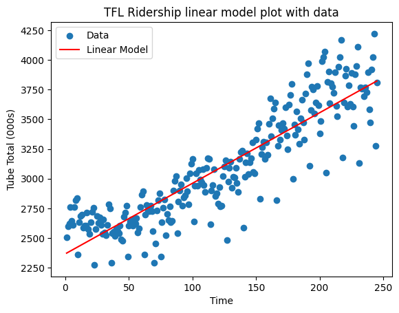

```
The MSE is 45323.636, and the R^2 is 0.796
```

```python
#Your code here
X = np.column_stack((np.ones(N),xvals))
XT = X.T #transpose of X
beta_linear = np.linalg.inv(XT.dot(X)).dot(XT.dot(yvals)) #linear regression coefficients using least squares
print(f'b0 = {beta_linear[0]:.2f}, b1 = {beta_linear[1]:.2f}')

linear_vals = beta_linear[0] + beta_linear[1]*xvals
plt.scatter(xvals,yvals, label='Data')
plt.plot()
plt.plot(xvals,linear_vals,'r', label='Linear Model')
plt.legend()
plt.xlabel('Time')
plt.ylabel('Tube Total (000s)')
plt.title('TFL Ridership linear model plot with data')
plt.savefig('Exercise 2b linear model plot with data.png')
plt.show()

SSE_linear = np.sum((yvals - linear_vals)**2)
MSE_linear = SSE_linear/(N)
R2_linear = 1 - SSE_linear/np.sum((yvals - np.mean(yvals))**2)
print(f'The MSE is {MSE_linear:.3f}, and the R^2 is {R2_linear:.3f}')
```

## 2c) Plotting the residuals

- Plot the residuals on a scatterplot
- Also plot the residuals over a short duration and comment on whether you can discern any periodic components.

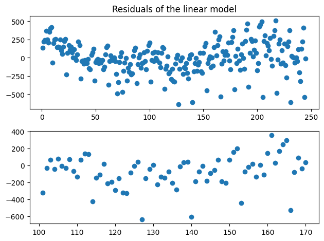

```python
# Your code here
linear_residuals = yvals - linear_vals
plt.xlabel('Time')
plt.ylabel('Tube Total (000s)')

plt.subplot(211)
plt.scatter(xvals, linear_residuals)
plt.title('Residuals of the linear model')
plt.subplot(212)
plt.scatter(xvals[100:170], linear_residuals[100:170])
plt.savefig('Exercise 2c Residuals of linear plot.png')
plt.tight_layout()
plt.show()
```

## 2d) Periodogram

- Compute and plot the peridogram of the residuals. (Recall that the periodogram is the squared-magnitude of the DFT coefficients.)
- Identify the indices/frequencies for which the periogram value exceeds **50%** of the maximum.

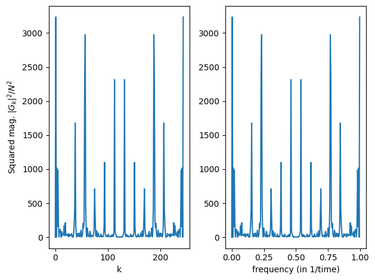

```python
# Your code to compute and plot the histogram
T = xvals[1] - xvals[0]  # This can be the time interval between any two successive values.

# Compute the squared magnitudes of the DFT coefficients -- this is known as the "periodogram"
pgram = np.abs(np.fft.fft(linear_residuals, N)/N)**2 #We normalize by N, but this is optional
indices = np.linspace(0, (N-1), num = N)
freqs_in_hz = indices/(N*T)
freqs_in_rads = freqs_in_hz*2*math.pi

plt.subplot(121)
plt.plot(indices, pgram)
plt.xlabel('k')
plt.ylabel('Squared mag. $|G_k|^2/N^2$')
plt.subplot(122)
plt.plot(freqs_in_hz, pgram)
plt.xlabel('frequency (in 1/time)')  # Since units of T is time
plt.savefig('exercise 2d periodogram of residuals.png')
plt.tight_layout()
plt.show()
```

```python
# Your code to identify the indices for which the periodogram value exceeds 50% of the maximum
def find_indicies(pgram):
    top_inds = indices[(pgram > 0.5*np.max(pgram))]
    return top_inds[:len(top_inds)//2]

large_indicies = find_indicies(pgram)
large_freqs_in_rads = large_indicies/(N*T) *2*math.pi
print(f'The frequencies in rads are {large_freqs_in_rads}')
```

```
The frequencies in rads are [0.02564565 0.97453486 1.43615664 1.4618023  2.89795894]
```

## 2e) To the residuals, fit a model of the form

$$ \beta_{1s} \sin(\omega_1 x) + \beta_{1c} \cos(\omega_1 x) + \beta_{2s} \sin(\omega_2 x) + \beta_{2c} \cos(\omega_2 x) + \ldots + \beta_{Ks} \sin(\omega_K x) + \beta_{Kc} \cos(\omega_K x).$$

The frequencies $\omega_1, \ldots, \omega_K$ in the model are those corresponding to the indices identified in Part 2c. (Hint: Each of the sines and cosines will correspond to one column in your X-matrix.)

- Print the values of the regression coefficients obtained using least-squares.
- Compute and print the final **MSE** and $R^2$ coefficient. Comment on the improvement over the linear fit.

All numerical outputs should be displayed to three decimal places.

```
Beta values are [-51.253 101.556  61.628 -54.006 -15.581 -94.797  81.659  72.381  32.472
  90.589]
```

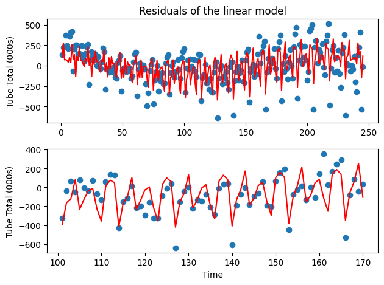

```
The MSE is 20297.501, and the R^2 is 0.552
```

```python
# Your code here

XT = np.vstack([[np.sin(w*xvals), np.cos(w*xvals)] for w in large_freqs_in_rads])
X = XT.T

beta_sins = np.linalg.inv(XT.dot(X)).dot(XT).dot(linear_residuals) # we want to fit the sinusoids to the residuals from the linear fit
print(f'Beta values are {beta_sins.round(3)}')

sin_values = X.dot(beta_sins)



plt.subplot(211)
plt.ylabel('Tube Total (000s)')
plt.scatter(xvals, linear_residuals)
plt.plot(xvals, sin_values, 'r')
plt.title('Residuals of the linear model')
plt.subplot(212)
plt.xlabel('Time')
plt.ylabel('Tube Total (000s)')
plt.scatter(xvals[100:170], linear_residuals[100:170])
plt.plot(xvals[100:170], sin_values[100:170], 'r')
plt.savefig('Exercise 2e sinusodial model to fit linear residuals.png')
plt.tight_layout()
plt.show()

SSE_sin = np.sum((linear_residuals - sin_values)**2)
MSE_sin = SSE_sin/(N)
R2_sin = 1 - SSE_sin/np.sum((linear_residuals - np.mean(linear_residuals))**2)
print(f'The MSE is {MSE_sin:.3f}, and the R^2 is {R2_sin:.3f}')
```

## 2f) The combined fit

- Plot the combined fit together with a scatterplot of the data
- Compute and print the final **MSE** and $R^2$ coefficient. Comment on the improvement over the linear fit.

The combined fit, which corresponds to the full model

$$ f(x) = \beta_0 + \beta_1 x + \beta_{s1} \sin(\omega_1 x) + \beta_{c1} \cos(\omega_1 x) + \ldots + \beta_{sk} \sin(\omega_k x) + \beta_{ck} \cos(\omega_k x), $$

can be obtained by adding the fits in parts 2b) and 2e).

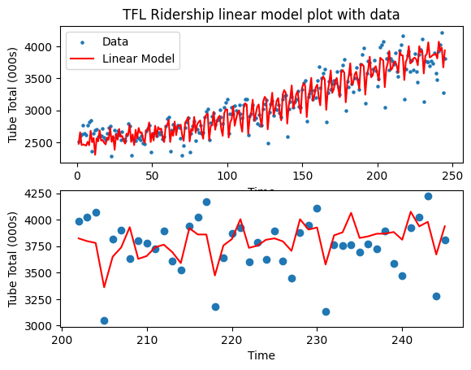

```
The MSE of the combined fit is 20297.501, and the R^2 is 0.908
The MSE of the linear fit is 45323.636, and the R^2 is 0.796
Therefore the combined fit MSE is 55.217% better than the linear fit
The combined fit R^2 is 14.185% better than the linear fit
```

```python
# Your code here
combined_vals = linear_vals + sin_values
plt.subplot(211)
plt.scatter(xvals,yvals, label='Data',s=5)
plt.plot(xvals,combined_vals,'r', label='Linear Model')
plt.legend()
plt.xlabel('Time')
plt.ylabel('Tube Total (000s)')
plt.title('TFL Ridership linear model plot with data')

plt.subplot(212)
plt.xlabel('Time')
plt.ylabel('Tube Total (000s)')
plt.scatter(xvals[201:250], yvals[201:250])
plt.plot(xvals[201:250], combined_vals[201:250], 'r')
plt.savefig('Exercise 2e linear+sin model plot with data.png')
plt.show()

SSE_combined = np.sum((yvals - combined_vals)**2)
MSE_combined = SSE_combined/(N)
R2_combined = 1 - SSE_combined/np.sum((yvals - np.mean(yvals))**2)
print(f'The MSE of the combined fit is {MSE_combined:.3f}, and the R^2 is {R2_combined:.3f}')
print(f'The MSE of the linear fit is {MSE_linear:.3f}, and the R^2 is {R2_linear:.3f}')
print(f'Therefore the combined fit MSE is {(MSE_linear - MSE_combined)/MSE_linear*100:.3f}% better than the linear fit')
print(f'The combined fit R^2 is {(R2_combined - R2_linear)/R2_linear*100:.3f}% better than the linear fit')
```